# IODS course project

## Standardising the dataset

```r
boston_scaled <- scale(Boston)
summary(boston_scaled)
```

```
##       crim                 zn               indus
##  Min.   :-0.419367   Min.   :-0.48724   Min.   :-1.5563
##  1st Qu.:-0.410563   1st Qu.:-0.48724   1st Qu.:-0.8668
##  Median :-0.390280   Median :-0.48724   Median :-0.2109
##  Mean   : 0.000000   Mean   : 0.00000   Mean   : 0.0000
##  3rd Qu.: 0.007389   3rd Qu.: 0.04872   3rd Qu.: 1.0150
##  Max.   : 9.924110   Max.   : 3.80047   Max.   : 2.4202
##       chas              nox                rm               age
##  Min.   :-0.2723   Min.   :-1.4644   Min.   :-3.8764   Min.   :-2.3331
##  1st Qu.:-0.2723   1st Qu.:-0.9121   1st Qu.:-0.5681   1st Qu.:-0.8366
##  Median :-0.2723   Median :-0.1441   Median :-0.1084   Median : 0.3171
##  Mean   : 0.0000   Mean   : 0.0000   Mean   : 0.0000   Mean   : 0.0000
##  3rd Qu.:-0.2723   3rd Qu.: 0.5981   3rd Qu.: 0.4823   3rd Qu.: 0.9059
##  Max.   : 3.6648   Max.   : 2.7296   Max.   : 3.5515   Max.   : 1.1164
##       dis               rad               tax             ptratio
##  Min.   :-1.2658   Min.   :-0.9819   Min.   :-1.3127   Min.   :-2.7047
##  1st Qu.:-0.8049   1st Qu.:-0.6373   1st Qu.:-0.7668   1st Qu.:-0.4876
##  Median :-0.2790   Median :-0.5225   Median :-0.4642   Median : 0.2746
##  Mean   : 0.0000   Mean   : 0.0000   Mean   : 0.0000   Mean   : 0.0000
##  3rd Qu.: 0.6617   3rd Qu.: 1.6596   3rd Qu.: 1.5294   3rd Qu.: 0.8058
##  Max.   : 3.9566   Max.   : 1.6596   Max.   : 1.7964   Max.   : 1.6372
##      black             lstat              medv
##  Min.   :-3.9033   Min.   :-1.5296   Min.   :-1.9063
##  1st Qu.: 0.2049   1st Qu.:-0.7986   1st Qu.:-0.5989
##  Median : 0.3808   Median :-0.1811   Median :-0.1449
##  Mean   : 0.0000   Mean   : 0.0000   Mean   : 0.0000
##  3rd Qu.: 0.4332   3rd Qu.: 0.6024   3rd Qu.: 0.2683
##  Max.   : 0.4406   Max.   : 3.5453   Max.   : 2.9865
```

```r
boston_scaled <- as.data.frame(boston_scaled)
```

As the above summary shows, as a result of the scaling, all variables now have zero as their mean.

Now I turn crime rate or `crim` into a categorical variable by first binning the observations and then using the bins as categorical classes. There will be four bins based on the quantiles of the variable.

```r
bins <- quantile(c(boston_scaled$crim))
crime <- cut(boston_scaled$crim, breaks = bins, include.lowest = TRUE, label = c("low", "med_low", "med_high", "high"))
table(crime)
```

```
## crime
##      low  med_low med_high     high
##      127      126      126      127
```

Finally, I can use `dplyr` to remove the old `crim` variable from the dataset and add the new `crime` variable to in in the former’s stead.

```r
library(dplyr)
boston_scaled <- dplyr::select(boston_scaled, -crim)
boston_scaled <- data.frame(boston_scaled, crime)
str(boston_scaled)
```

```
## 'data.frame':    506 obs. of  14 variables:
##  $ zn     : num  0.285 -0.487 -0.487 -0.487 -0.487 ...
##  $ indus  : num  -1.287 -0.593 -0.593 -1.306 -1.306 ...
##  $ chas   : num  -0.272 -0.272 -0.272 -0.272 -0.272 ...
##  $ nox    : num  -0.144 -0.74 -0.74 -0.834 -0.834 ...
##  $ rm     : num  0.413 0.194 1.281 1.015 1.227 ...
##  $ age    : num  -0.12 0.367 -0.266 -0.809 -0.511 ...
##  $ dis    : num  0.14 0.557 0.557 1.077 1.077 ...
##  $ rad    : num  -0.982 -0.867 -0.867 -0.752 -0.752 ...
##  $ tax    : num  -0.666 -0.986 -0.986 -1.105 -1.105 ...
##  $ ptratio: num  -1.458 -0.303 -0.303 0.113 0.113 ...
##  $ black  : num  0.441 0.441 0.396 0.416 0.441 ...
##  $ lstat  : num  -1.074 -0.492 -1.208 -1.36 -1.025 ...
##  $ medv   : num  0.16 -0.101 1.323 1.182 1.486 ...
##  $ crime  : Factor w/ 4 levels "low","med_low",..: 1 1 1 1 1 1 2 2 2 2 ...
```

## Creating the test set and the train set

Before the actual analysis, I need a test set and a train set in order to be able to determine how well my analysis actually fits the data. 80% of the data will be in the train set, the rest in the test set.

```r
n <- nrow(boston_scaled)
ind <- sample(n,  size = n * 0.8)
train <- boston_scaled[ind,]
test <- boston_scaled[-ind,]
```

We can confirm that this took place by looking at the structure and dimensions of the two subsets of data.

```r
str(train); dim(train)
```

```
## 'data.frame':    404 obs. of  14 variables:
##  $ zn     : num  -0.4872 0.0487 -0.4872 0.3703 -0.4872 ...
##  $ indus  : num  -0.593 -0.739 -0.211 -1.138 -0.18 ...
##  $ chas   : num  -0.272 -0.272 -0.272 -0.272 -0.272 ...
##  $ nox    : num  -0.7395 -1.2573 0.2615 -0.9648 -0.0923 ...
##  $ rm     : num  0.194 -0.579 -0.822 0.751 0.499 ...
##  $ age    : num  0.367 -1.676 -0.518 -1.292 0.495 ...
##  $ dis    : num  0.557 1.284 -0.671 0.145 -0.227 ...
##  $ rad    : num  -0.867 -0.637 -0.408 -0.522 -0.637 ...
##  $ tax    : num  -0.986 -0.375 -0.102 -1.141 -0.618 ...
##  $ ptratio: num  -0.3028 0.2053 0.3439 -1.6423 -0.0257 ...
##  $ black  : num  0.441 0.433 0.441 0.441 0.441 ...
##  $ lstat  : num  -0.492 -0.6376 -0.0901 -1.0927 -1.1361 ...
##  $ medv   : num  -0.1014 -0.0579 -0.0797 1.3664 0.0291 ...
##  $ crime  : Factor w/ 4 levels "low","med_low",..: 1 1 2 2 3 2 3 1 1 3 ...
```

```
## [1] 404  14
```

```r
str(test); dim(test)
```

```
## 'data.frame':    102 obs. of  14 variables:
##  $ zn     : num  0.0487 -0.4872 -0.4872 -0.4872 -0.4872 ...
##  $ indus  : num  -0.476 -0.437 -0.437 -0.437 -0.437 ...
##  $ chas   : num  -0.272 -0.272 -0.272 -0.272 -0.272 ...
##  $ nox    : num  -0.265 -0.144 -0.144 -0.144 -0.144 ...
##  $ rm     : num  0.131 -0.641 -0.419 -0.203 -0.671 ...
##  $ age    : num  0.914 -0.429 0.466 0.822 0.772 ...
##  $ dis    : num  1.2118 0.3341 0.2198 0.0864 0.4212 ...
##  $ rad    : num  -0.522 -0.637 -0.637 -0.637 -0.637 ...
##  $ tax    : num  -0.577 -0.601 -0.601 -0.601 -0.601 ...
##  $ ptratio: num  -1.5 1.18 1.18 1.18 1.18 ...
##  $ black  : num  0.393 0.427 0.329 0.441 0.221 ...
##  $ lstat  : num  1.092 -0.586 0.282 0.85 0.302 ...
##  $ medv   : num  -0.819 -0.286 -0.547 -0.797 -0.645 ...
##  $ crime  : Factor w/ 4 levels "low","med_low",..: 2 3 3 3 3 3 3 3 1 1 ...
```

```
## [1] 102  14
```

As the outputs show, the train data has 404 observations, while the test data has only 102 observations (but both have the same number of variables, 14).

## Linear discriminant analysis

I am now in a position to fit the linear discriminant analysis on the train set of the data. The categorical crime rate is the target variable, and all other variables are predictors.

```r
lda.fit <- lda(crime ~ ., data = train)
lda.fit
```

```
## Call:
## lda(crime ~ ., data = train)
##
## Prior probabilities of groups:
##       low   med_low  med_high      high
## 0.2500000 0.2524752 0.2376238 0.2599010
##
## Group means:
##                   zn      indus        chas        nox          rm
## low       1.08074698 -0.9788554 -0.11640431 -0.9506868  0.49388089
## med_low  -0.07381211 -0.4013419 -0.07933396 -0.6030697 -0.11460942
## med_high -0.37826080  0.2233839  0.17879700  0.4452679  0.07012619
## high     -0.48724019  1.0170492 -0.04735191  1.0095226 -0.44029412
##                 age        dis        rad        tax     ptratio
## low      -0.9105287  0.9609998 -0.6987343 -0.7315104 -0.50630727
## med_low  -0.3947640  0.4023292 -0.5427515 -0.5020823 -0.07954023
## med_high  0.4502141 -0.4042935 -0.4064414 -0.2915880 -0.32348401
## high      0.7832628 -0.8437682  1.6388211  1.5145512  0.78158339
##                black       lstat        medv
## low       0.38126301 -0.80023795  0.60252130
## med_low   0.31725887 -0.17883656  0.02617379
## med_high  0.06617556  0.03757017  0.15579020
## high     -0.78192197  0.87580465 -0.66309140
##
## Coefficients of linear discriminants:
##                 LD1         LD2         LD3
## zn       0.06435789  0.54868071 -1.03002964
## indus    0.10060303 -0.52266635  0.02463321
## chas    -0.07490984 -0.08599416  0.06692929
## nox      0.34951312 -0.77946448 -1.08506945
## rm      -0.08566469 -0.07738886 -0.17515768
## age      0.25768902 -0.30788283 -0.23971364
## dis     -0.07275648 -0.20104805  0.10155409
## rad      3.23820948  0.79623183 -0.07800176
## tax     -0.06767747  0.37501645  0.47608975
## ptratio  0.11519434 -0.03036732 -0.19046332
## black   -0.11216245 -0.00283191  0.11269587
## lstat    0.22887755 -0.06494429  0.26537357
## medv     0.20350611 -0.22874659 -0.25470949
##
## Proportion of trace:
##    LD1    LD2    LD3
## 0.9448 0.0430 0.0122
```

The LDA is then plotted using a biplot.

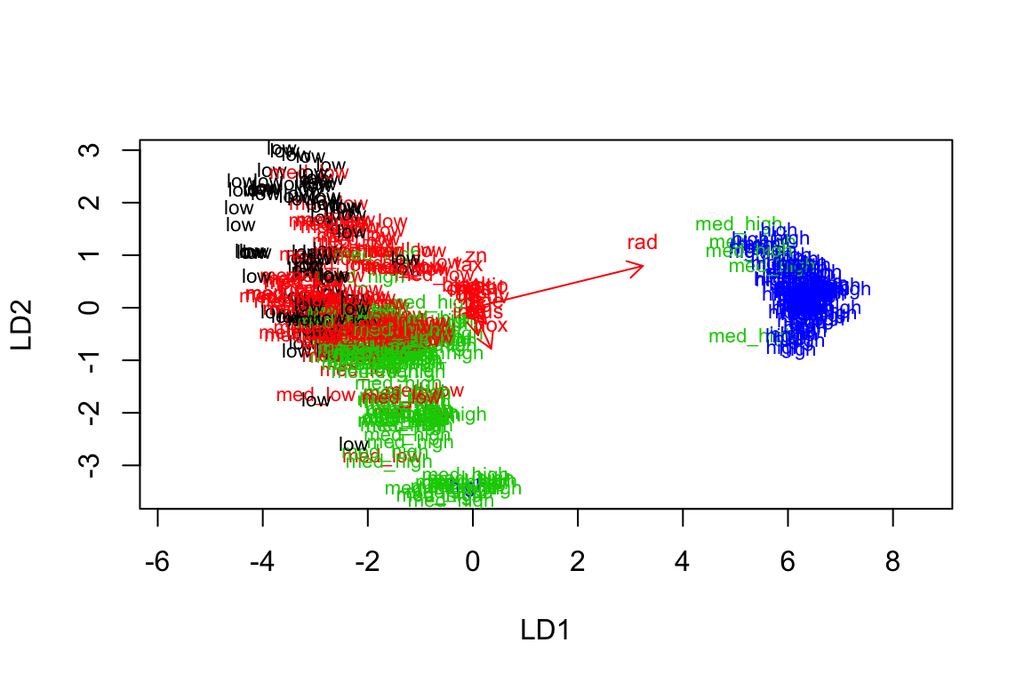

```r
lda.arrows <- function(x, myscale = 1, arrow_heads = 0.1, color = "red", tex = 0.75, choices = c(1,2)){
  heads <- coef(x)
  arrows(x0 = 0, y0 = 0,
         x1 = myscale * heads[,choices[1]],
         y1 = myscale * heads[,choices[2]], col=color, length = arrow_heads)
  text(myscale * heads[,choices], labels = row.names(heads),
       cex = tex, col=color, pos=3)
}
classes <- as.numeric(train$crime)
plot(lda.fit, dimen = 2, col = classes, pch = classes)
lda.arrows(lda.fit, myscale = 1)
```

## Predicting

First, I save the vector that includes the classification of the test set according to the binned crime levels.

```r
correct_classes <- test$crime
```

I then remove the `crime` variable from the test set.

```r
test <- dplyr::select(test, -crime)
str(test)
```

```
## 'data.frame':    102 obs. of  13 variables:
##  $ zn     : num  0.0487 -0.4872 -0.4872 -0.4872 -0.4872 ...
##  $ indus  : num  -0.476 -0.437 -0.437 -0.437 -0.437 ...
##  $ chas   : num  -0.272 -0.272 -0.272 -0.272 -0.272 ...
##  $ nox    : num  -0.265 -0.144 -0.144 -0.144 -0.144 ...
##  $ rm     : num  0.131 -0.641 -0.419 -0.203 -0.671 ...
##  $ age    : num  0.914 -0.429 0.466 0.822 0.772 ...
##  $ dis    : num  1.2118 0.3341 0.2198 0.0864 0.4212 ...
##  $ rad    : num  -0.522 -0.637 -0.637 -0.637 -0.637 ...
##  $ tax    : num  -0.577 -0.601 -0.601 -0.601 -0.601 ...
##  $ ptratio: num  -1.5 1.18 1.18 1.18 1.18 ...
##  $ black  : num  0.393 0.427 0.329 0.441 0.221 ...
##  $ lstat  : num  1.092 -0.586 0.282 0.85 0.302 ...
##  $ medv   : num  -0.819 -0.286 -0.547 -0.797 -0.645 ...
```

After that, I check how well the analysis predicts unseen data, i.e. the test set.

```r
lda.pred <- predict(lda.fit, newdata = test)
table(correct = correct_classes, predicted = lda.pred$class)
```

```
##           predicted
## correct    low med_low med_high high
##   low       10      14        2    0
##   med_low    2      15        7    0
##   med_high   0      14       15    1
##   high       0       0        0   22
```

## Clustering

Lastly, I shall apply k-means clustering to the `Boston` dataset. I first need to download the original dataset and scale it again.

```r
data("Boston")
boston_scaled <- scale(Boston)
```

I shall make the clustering analysis using Euclidean distances. First, I calculate these, and then I perform the k-means clustering itself. Finally, I plot the clusters.

[figure not shown]

```r
dist_eu <- dist(boston_scaled)
km <-kmeans(dist_eu, centers = 10)
pairs(boston_scaled, col = km$cluster)
```

However, this is only a first stab on the clusters since I have not yet determined the correct number of clusters in the data. To do this, I need to calculate the total within cluster sum of squares (WCSS) and inspect the result visually to see where the plot ‘elbows’.

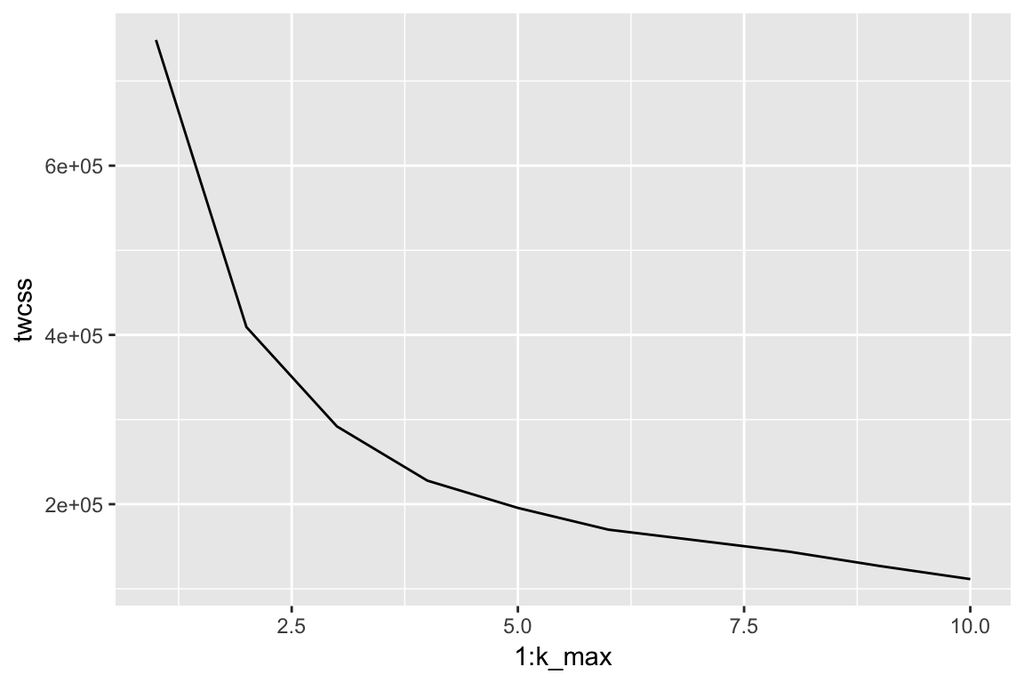

```r
k_max <- 10
twcss <- sapply(1:k_max, function(k){kmeans(dist_eu, k)$tot.withinss})
qplot(x = 1:k_max, y = twcss, geom = 'line')
```

[figure not shown]

```r
km <-kmeans(dist_eu, centers = 10)
pairs(boston_scaled, col = km$cluster)
```

# Exercise 5: Dimensionality reduction techniques

## Preliminaries

We begin by loading the dataset into R.

```r
human <- read.csv("http://s3.amazonaws.com/assets.datacamp.com/production/course_2218/datasets/human2.txt", header = TRUE)
```

We then explore the dataset.

```r
str(human)
```

```
## 'data.frame':    155 obs. of  8 variables:
##  $ Edu2.FM  : num  1.007 0.997 0.983 0.989 0.969 ...
##  $ Labo.FM  : num  0.891 0.819 0.825 0.884 0.829 ...
##  $ Edu.Exp  : num  17.5 20.2 15.8 18.7 17.9 16.5 18.6 16.5 15.9 19.2 ...
##  $ Life.Exp : num  81.6 82.4 83 80.2 81.6 80.9 80.9 79.1 82 81.8 ...
##  $ GNI      : int  64992 42261 56431 44025 45435 43919 39568 52947 42155 32689 ...
##  $ Mat.Mor  : int  4 6 6 5 6 7 9 28 11 8 ...
##  $ Ado.Birth: num  7.8 12.1 1.9 5.1 6.2 3.8 8.2 31 14.5 25.3 ...
##  $ Parli.F  : num  39.6 30.5 28.5 38 36.9 36.9 19.9 19.4 28.2 31.4 ...
```

```r
dim(human)
```

```
## [1] 155   8
```

The `human` dataset contains various indicators of the well-being of various countries. As the summary shows, there are altogether 155 observations (i.e. countries). The variables are the following:  
* `Edu2.FM`: the ratio of females to males in secondary education  
* `Labo.FM`: the ratio of females to males in the labour force  
* `Edu.Exp`: expected number of years spent in schooling  
* `Life.Exp`: life expectancy in years  
* `GNI`: gross national income  
* `Mat.Mor`: the relativised number of mothers who die at childbirth  
* `Ado.Birth`: the rate of teenage pregnancies leading to childbirth  
* `Parli.F`: the percentage of female parliamentarians

## Overview of the variables

We may now have a look at the variables in more detail. First, we have a look at their distributions.

```r
library(GGally)
```

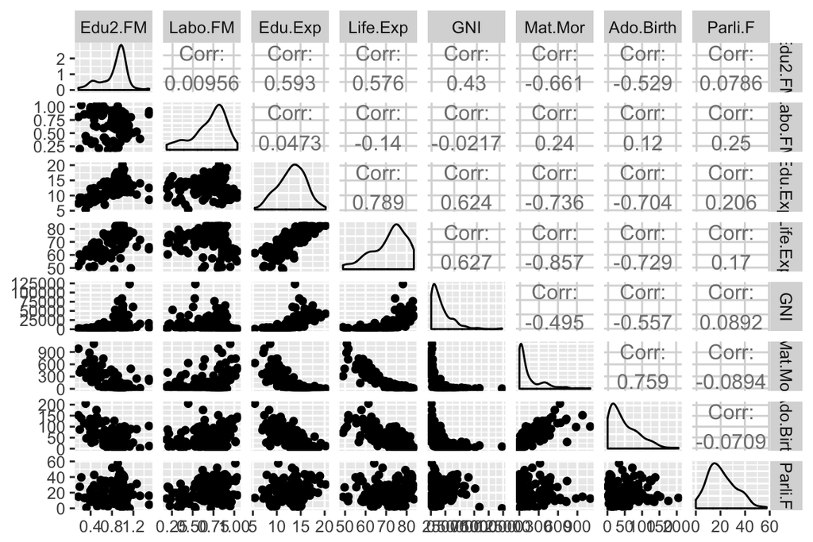

```r
ggpairs(human)
```

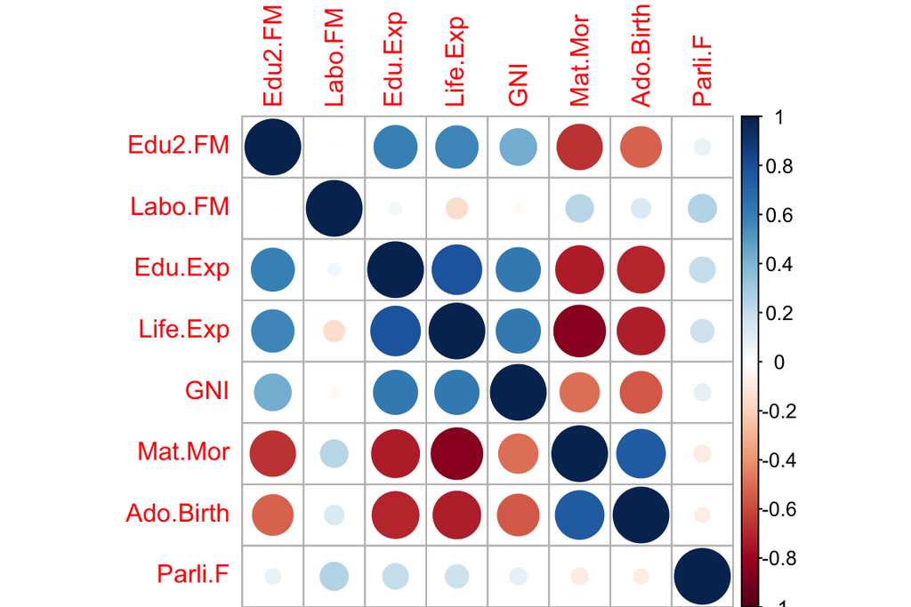

```r
library(dplyr)
library(corrplot)
cor(human) %>% corrplot
```

There are strong positive correlations between adolescent birth rate and maternal mortality on the one hand, and life expectancy and expected years spent in schooling on the other. The strongest negative correlation is between maternal mortality and life expectancy. Other strongly negative correlations obtain between maternal mortality and ratio of females to males in secondary education; maternal mortality and expected years spent in schooling; adolescent birthrate and expected years spent in schooling; as well as adolescent birthrate and life expectancy. By contrast, the ration of females to males in the labour market and the proportion of female parliamentarians are only weakly if at all correlated with the other variables.

## PCA on non-standardised data

Now we perform our first attempt at a Principal Component Analysis (PCA) of the dataset. Note that we have not standardised the numeric predictors at this stage, and as we saw above, the variables are quite divergent in their distributional properties. We also visualise the analysis by means of a biplot.

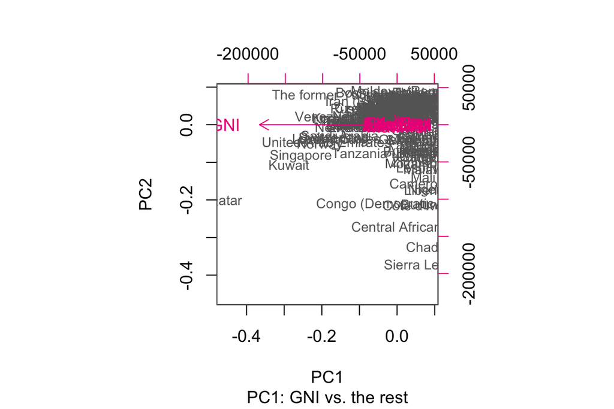

```r
pca_human <- prcomp(human)
biplot(pca_human, choices = 1:2, cex = c(0.8, 1), col = c("grey40", "deeppink2"), sub = "PC1: GNI vs. the rest")
```

The biplot is not very informative: the first PCA does not really succeed in teasing out the structure in the data. The only variable that is visible in the plot is the GNI, which aligns almost perfectly with PC1.

## PCA on standardised data

Since the first PCA was not a success, we need to go back to the drawing board and standardise the variables. As all variables are numeric, we may scale the whole dataset.

```r
human_scale <- scale(human)
summary(human_scale)
```

```
##     Edu2.FM           Labo.FM           Edu.Exp           Life.Exp
##  Min.   :-2.8189   Min.   :-2.6247   Min.   :-2.7378   Min.   :-2.7188
##  1st Qu.:-0.5233   1st Qu.:-0.5484   1st Qu.:-0.6782   1st Qu.:-0.6425
##  Median : 0.3503   Median : 0.2316   Median : 0.1140   Median : 0.3056
##  Mean   : 0.0000   Mean   : 0.0000   Mean   : 0.0000   Mean   : 0.0000
##  3rd Qu.: 0.5958   3rd Qu.: 0.7350   3rd Qu.: 0.7126   3rd Qu.: 0.6717
##  Max.   : 2.6646   Max.   : 1.6632   Max.   : 2.4730   Max.   : 1.4218
##       GNI             Mat.Mor          Ado.Birth          Parli.F
##  Min.   :-0.9193   Min.   :-0.6992   Min.   :-1.1325   Min.   :-1.8203
##  1st Qu.:-0.7243   1st Qu.:-0.6496   1st Qu.:-0.8394   1st Qu.:-0.7409
##  Median :-0.3013   Median :-0.4726   Median :-0.3298   Median :-0.1403
##  Mean   : 0.0000   Mean   : 0.0000   Mean   : 0.0000   Mean   : 0.0000
##  3rd Qu.: 0.3712   3rd Qu.: 0.1932   3rd Qu.: 0.6030   3rd Qu.: 0.6127
##  Max.   : 5.6890   Max.   : 4.4899   Max.   : 3.8344   Max.   : 3.1850
```

As the `summary` function’s output shows, all variables now have zero as their mean.  
Let us now give another go at PCA’ing the data.

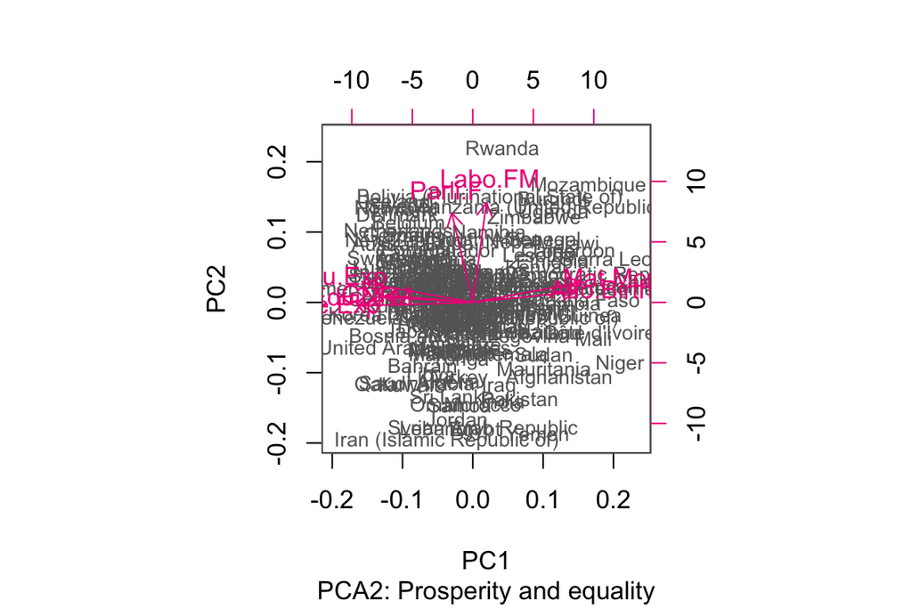

```r
pca_human_scale <- prcomp(human_scale)
biplot(pca_human_scale, choices = 1:2, cex = c(0.8, 1), col = c("grey40", "deeppink2"), sub = "PCA2: Prosperity and equality")
```

The result is a much clearer picture, with some variables associated clearly with PC1 and others with PC2.

## Interpreting the PCA

The variables form three broad groups in the second PCA analysis.  
* The first group consists of variables `Edu.Exp`, `Edu2.FM`, `Life.Exp` and `GNI`. They are all very closely aligned with negative values of PC1. A high score in these variables is associated with western countries. They display equality, well-being and prosperity.  
* The second group consists of variables `Mat.Mor` and `Ado.Birth`. They are also associated with PC1, but correlate positively with it and are thus diametrically opposite to the first group. They display a lack of basic healthcare.  
* The third group consists of variables `Labo.FM` and `Parli.F`. They are associated with PC2. Recall that these variables had little correlation with the others. They are related to formal gender equality, which, interestingly, may be fulfilled in both rich and poor countries.

## MCA

For the final part of this exercise, we perform a Multiple Correspondence Analysis (MCA) on another dataset. This is the `tea` dataset from the package `FactoMineR`, which we shall first read into R.

```r
library(FactoMineR)
data(tea)
str(tea)
```

```
## 'data.frame':    300 obs. of  36 variables:
##  $ breakfast       : Factor w/ 2 levels "breakfast","Not.breakfast": 1 1 2 2 1 2 1 2 1 1 ...
##  $ tea.time        : Factor w/ 2 levels "Not.tea time",..: 1 1 2 1 1 1 2 2 2 1 ...
##  $ evening         : Factor w/ 2 levels "evening","Not.evening": 2 2 1 2 1 2 2 1 2 1 ...
##  $ lunch           : Factor w/ 2 levels "lunch","Not.lunch": 2 2 2 2 2 2 2 2 2 2 ...
##  $ dinner          : Factor w/ 2 levels "dinner","Not.dinner": 2 2 1 1 2 1 2 2 2 2 ...
##  $ always          : Factor w/ 2 levels "always","Not.always": 2 2 2 2 1 2 2 2 2 2 ...
##  $ home            : Factor w/ 2 levels "home","Not.home": 1 1 1 1 1 1 1 1 1 1 ...
##  $ work            : Factor w/ 2 levels "Not.work","work": 1 1 2 1 1 1 1 1 1 1 ...
##  $ tearoom         : Factor w/ 2 levels "Not.tearoom",..: 1 1 1 1 1 1 1 1 1 2 ...
##  $ friends         : Factor w/ 2 levels "friends","Not.friends": 2 2 1 2 2 2 1 2 2 2 ...
##  $ resto           : Factor w/ 2 levels "Not.resto","resto": 1 1 2 1 1 1 1 1 1 1 ...
##  $ pub             : Factor w/ 2 levels "Not.pub","pub": 1 1 1 1 1 1 1 1 1 1 ...
##  $ Tea             : Factor w/ 3 levels "black","Earl Grey",..: 1 1 2 2 2 2 2 1 2 1 ...
##  $ How             : Factor w/ 4 levels "alone","lemon",..: 1 3 1 1 1 1 1 3 3 1 ...
```

[output cut: 22 more lines]

```r
dim(tea)
```

```
## [1] 300  36
```

Now we can perform the MCA on the dataset.

```r
keep_columns <- c("Tea", "How", "how", "sugar", "where", "lunch")
tea_time <- dplyr::select(tea, one_of(keep_columns))
mca <- MCA(tea_time, graph = FALSE)
summary(mca)
```

```
##
## Call:
## MCA(X = tea_time, graph = FALSE)
##
##
## Eigenvalues
##                        Dim.1   Dim.2   Dim.3   Dim.4   Dim.5   Dim.6
## Variance               0.279   0.261   0.219   0.189   0.177   0.156
## % of var.             15.238  14.232  11.964  10.333   9.667   8.519
## Cumulative % of var.  15.238  29.471  41.435  51.768  61.434  69.953
##                        Dim.7   Dim.8   Dim.9  Dim.10  Dim.11
## Variance               0.144   0.141   0.117   0.087   0.062
## % of var.              7.841   7.705   6.392   4.724   3.385
## Cumulative % of var.  77.794  85.500  91.891  96.615 100.000
##
## Individuals (the 10 first)
##                       Dim.1    ctr   cos2    Dim.2    ctr   cos2    Dim.3
## 1                  | -0.298  0.106  0.086 | -0.328  0.137  0.105 | -0.327
## 2                  | -0.237  0.067  0.036 | -0.136  0.024  0.012 | -0.695
## 3                  | -0.369  0.162  0.231 | -0.300  0.115  0.153 | -0.202
## 4                  | -0.530  0.335  0.460 | -0.318  0.129  0.166 |  0.211
## 5                  | -0.369  0.162  0.231 | -0.300  0.115  0.153 | -0.202
## 6                  | -0.369  0.162  0.231 | -0.300  0.115  0.153 | -0.202
## 7                  | -0.369  0.162  0.231 | -0.300  0.115  0.153 | -0.202
## 8                  | -0.237  0.067  0.036 | -0.136  0.024  0.012 | -0.695
## 9                  |  0.143  0.024  0.012 |  0.871  0.969  0.435 | -0.067
## 10                 |  0.476  0.271  0.140 |  0.687  0.604  0.291 | -0.650
##                       ctr   cos2
## 1                   0.163  0.104 |
## 2                   0.735  0.314 |
## 3                   0.062  0.069 |
## 4                   0.068  0.073 |
## 5                   0.062  0.069 |
## 6                   0.062  0.069 |
## 7                   0.062  0.069 |
## 8                   0.735  0.314 |
## 9                   0.007  0.003 |
## 10                  0.643  0.261 |
##
## Categories (the 10 first)
```

[output cut: 16 more lines]

```
## lemon                0.035   3.226 |   1.329  14.771   0.218   8.081 |
## milk                 0.020   2.422 |   0.013   0.003   0.000   0.116 |
## other                0.102   5.534 |  -2.524  14.526   0.197  -7.676 |
## tea bag              0.161  -6.941 |  -0.065   0.183   0.006  -1.287 |
## tea bag+unpackaged   0.478  11.956 |   0.019   0.009   0.000   0.226 |
## unpackaged           0.141  -6.482 |   0.257   0.602   0.009   1.640 |
##
## Categorical variables (eta2)
##                      Dim.1 Dim.2 Dim.3
## Tea                | 0.126 0.108 0.410 |
## How                | 0.076 0.190 0.394 |
## how                | 0.708 0.522 0.010 |
## sugar              | 0.065 0.001 0.336 |
## where              | 0.702 0.681 0.055 |
## lunch              | 0.000 0.064 0.111 |
```

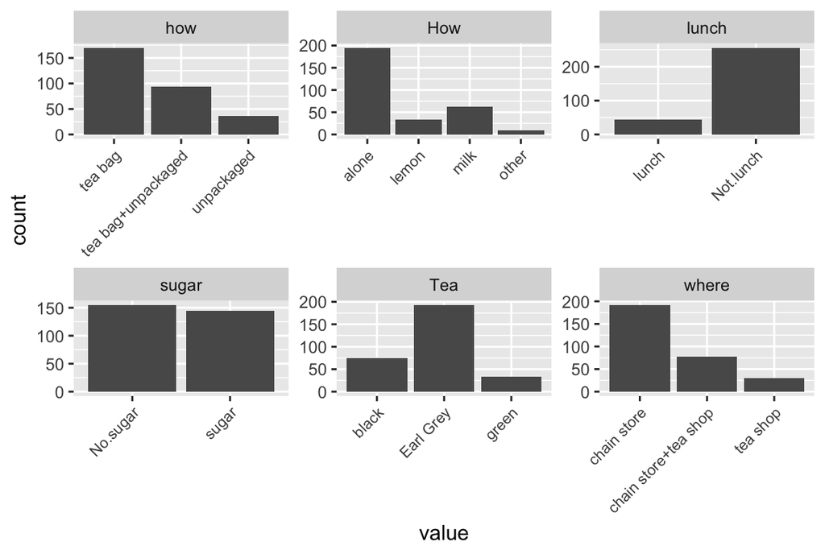

```r
library(tidyr); library(ggplot2)
gather(tea_time) %>% ggplot(aes(value)) + facet_wrap("key", scales = "free") + geom_bar() + theme(axis.text.x = element_text(angle = 45, hjust = 1, size = 8))
```

The plots show that the respondents’ tea habits are quite variable.